# Final Project

### Does Nature Know Best? Analyzing Activity in Nature & Mental Health

This final project investigates the relationship between activity in nature and mental health. First a chi-squared test is conducted, followed by three logistic regressions with one of the models accounting for two confounding variables.

**Hypothesis**: Individuals who are active in nature are more likely to report better mental health.

This project is based on the General Social Survey (GSS) 2021 data is found here: https://gss.norc.org/Get-The-Data

```r
#import libraries and more libraries
library(tidyverse)
library(dplyr)
library(descr)
library(haven)
library(DescTools)
library(vcd)
```

```r
library(ggplot2)
library(infer)
library(wesanderson)
library(lmtest)
```

#### Load GSS Data

```r
gss_2021 <- read_dta("gss2021.dta")

#view(gss_2021)
#colnames(gss_2021)
```

#### Select Variables and Drop NAs

```r
#select variables for analysis and drop NAs
data <- gss_2021 %>%
  select(id, hlthmntl,incom16, activnat, hlthphys, income16) %>% drop_na(hlthmntl, activnat)
data
```

| id | hlthmntl | incom16 | activnat | hlthphys | income16 |
| --- | --- | --- | --- | --- | --- |
| 6 | 2 | 3 | 4 | 1 | NA(d) |
| 7 | 3 | 3 | 4 | 3 | NA(d) |
| 8 | 4 | 3 | 3 | 3 | 22 |
| 9 | 2 | 3 | 2 | 2 | 22 |
| 13 | 4 | 2 | 3 | 4 | 21 |
| 16 | 4 | 4 | 3 | 4 | NA(d) |
| 17 | 1 | 3 | 3 | 3 | 26 |
| 23 | 3 | 2 | 4 | 3 | 21 |
| 25 | 4 | 3 | 4 | 4 | 25 |
| 28 | 2 | 2 | 4 | 2 | 25 |

[output cut: 1755 more lines]

#### Variable Histograms and Counts

Visualize the data and see counts for categories

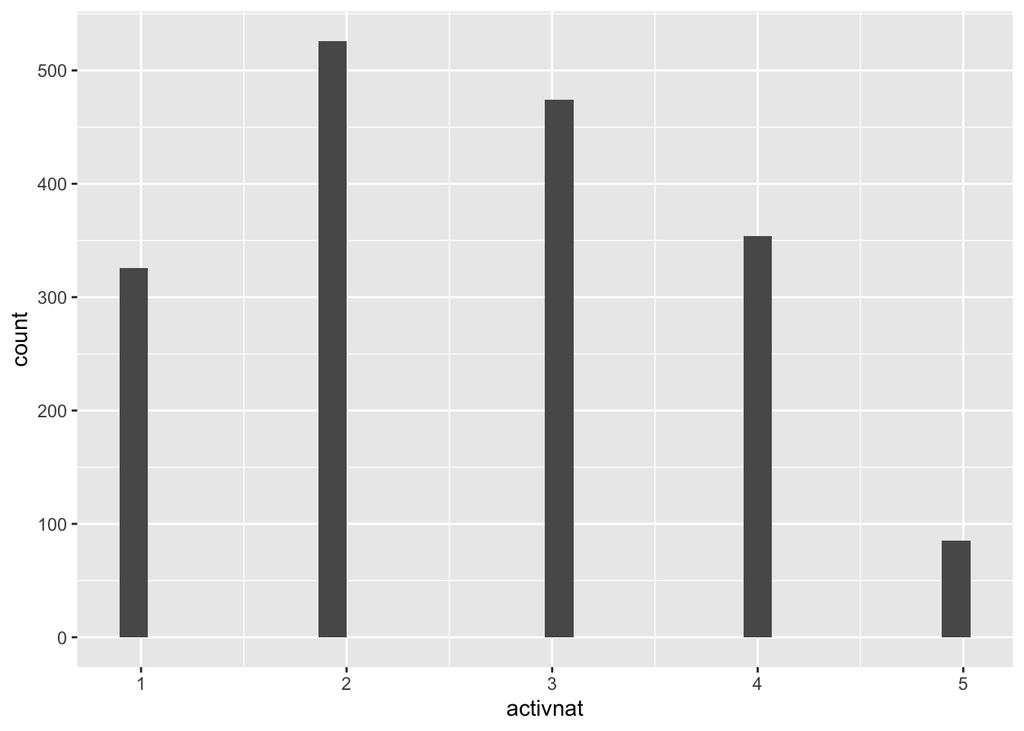

```r
#histograms
data %>%  ggplot(aes(x=activnat )) + geom_histogram()
```

```r
#counts of nature variables
data %>% count(activnat)
```

| activnat | n |
| --- | --- |
| 1 | 326 |
| 2 | 526 |
| 3 | 474 |
| 4 | 354 |
| 5 | 85 |

## Chi-Squared Test

The association between the categorical variables activnat and hlthmntl was highly significant with a p-value of 0.000013080. A similar story is reflected in the simulation-based null distribution visualization.

```r
#test data type
sapply(data, typeof)
```

```
##       id hlthmntl  incom16 activnat hlthphys income16
## "double" "double" "double" "double" "double" "double"
```

```r
#recode columns
data$activnat <- as.character(data$activnat)
data$hlthmntl <- as.character(data$hlthmntl)

#active in nature
observed <- data %>%
    specify(hlthmntl ~ activnat) %>%
    hypothesize(null = "independence") %>%
    calculate(stat = "Chisq") #chi squared distribution
observed
```

| stat |
| --- |
| 51.5219 |

```r
data %>%
    specify(hlthmntl ~ activnat) %>%
    hypothesize(null = "independence") %>%
    generate(reps = 1000, type = "permute") %>%
    calculate(stat = "Chisq") %>%
    visualize() +
    shade_p_value(observed, direction = "greater")
```

[figure not shown]

```r
chisq_test(x = data, hlthmntl ~ activnat)
```

| statistic | chisq_df | p_value |
| --- | --- | --- |
| 51.5219 | 16 | 1.308037e-05 |

#### Mosaic Plot and Pearson Residuals

Using a mosaic plot to visualize the cross between both variables and spot the Pearson Residuals.

```r
#create a mosaic plot from the table
tbl <- xtabs(~hlthmntl + activnat, data)
ftable(tbl)
```

```
##          activnat   1   2   3   4   5
## hlthmntl
## 1                  83  84  63  48   9
## 2                 116 215 186 119  23
## 3                  92 156 150 118  34
## 4                  30  53  58  57  12
## 5                   5  18  17  12   7
```

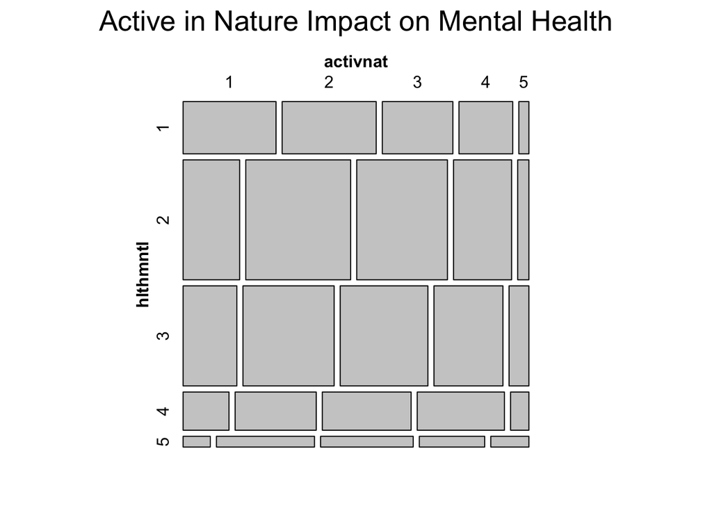

```r
mosaic(tbl, main = "Active in Nature Impact on Mental Health")
```

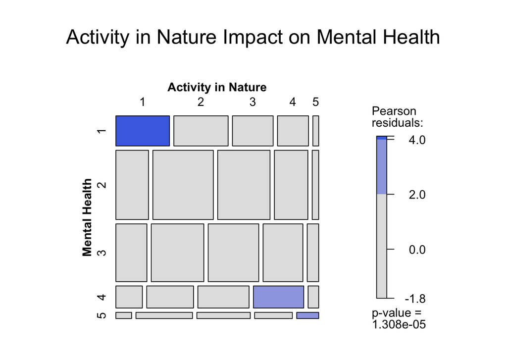

```r
#more detailed mosaic
mosaic(tbl,
       shade = TRUE,
       legend = TRUE,
       labeling_args = list(set_varnames = c(activnat = "Activity in Nature",
                                             hlthmntl = "Mental Health")),
       main = "Activity in Nature Impact on Mental Health")
```

#### Convert Mental Health into Binary (Two Ways)

Applying to thought processing to split the hlthmntl variable (mental health) into a binary.

```r
#recoding that only poor is compared to grouped other
data_poor <- data %>%
  mutate(mntl_poor = case_when(
  hlthmntl == 1 ~ 1,
  hlthmntl == 2 ~ 1,
  hlthmntl == 3 ~ 1,
  hlthmntl == 4 ~ 1,
  hlthmntl == 5 ~ 0,
))
data_poor
```

| id | hlthmntl | incom16 | activnat | hlthphys | income16 | mntl_poor |
| --- | --- | --- | --- | --- | --- | --- |
| 6 | 2 | 3 | 4 | 1 | NA(d) | 1 |
| 7 | 3 | 3 | 4 | 3 | NA(d) | 1 |
| 8 | 4 | 3 | 3 | 3 | 22 | 1 |
| 9 | 2 | 3 | 2 | 2 | 22 | 1 |
| 13 | 4 | 2 | 3 | 4 | 21 | 1 |
| 16 | 4 | 4 | 3 | 4 | NA(d) | 1 |
| 17 | 1 | 3 | 3 | 3 | 26 | 1 |
| 23 | 3 | 2 | 4 | 3 | 21 | 1 |
| 25 | 4 | 3 | 4 | 4 | 25 | 1 |
| 28 | 2 | 2 | 4 | 2 | 25 | 1 |

[output cut: 1755 more lines]

```r
#recoding the poor and fair grouped vs. all other
data_recode <- data %>%
  mutate(mntl_binary = case_when(
  hlthmntl == 1 ~ 1,
  hlthmntl == 2 ~ 1,
  hlthmntl == 3 ~ 1,
  hlthmntl == 4 ~ 0,
  hlthmntl == 5 ~ 0,
))
data_recode
```

| id | hlthmntl | incom16 | activnat | hlthphys | income16 | mntl_binary |
| --- | --- | --- | --- | --- | --- | --- |
| 6 | 2 | 3 | 4 | 1 | NA(d) | 1 |
| 7 | 3 | 3 | 4 | 3 | NA(d) | 1 |
| 8 | 4 | 3 | 3 | 3 | 22 | 0 |
| 9 | 2 | 3 | 2 | 2 | 22 | 1 |
| 13 | 4 | 2 | 3 | 4 | 21 | 0 |
| 16 | 4 | 4 | 3 | 4 | NA(d) | 0 |
| 17 | 1 | 3 | 3 | 3 | 26 | 1 |
| 23 | 3 | 2 | 4 | 3 | 21 | 1 |
| 25 | 4 | 3 | 4 | 4 | 25 | 0 |
| 28 | 2 | 2 | 4 | 2 | 25 | 1 |

[output cut: 1755 more lines]

```r
#visualization code for below (listed as a character)
data_text <- data %>%
  mutate(mntl_binary1 = case_when(
  hlthmntl == 1 ~ "good",
  hlthmntl == 2 ~ "good",
  hlthmntl == 3 ~ "good",
  hlthmntl == 4 ~ "bad",
  hlthmntl == 5 ~ "bad",
  TRUE~ as.character((hlthmntl)
)))
data_text
```

| id | hlthmntl | incom16 | activnat | hlthphys | income16 | mntl_binary1 |
| --- | --- | --- | --- | --- | --- | --- |
| 6 | 2 | 3 | 4 | 1 | NA(d) | good |
| 7 | 3 | 3 | 4 | 3 | NA(d) | good |
| 8 | 4 | 3 | 3 | 3 | 22 | bad |
| 9 | 2 | 3 | 2 | 2 | 22 | good |
| 13 | 4 | 2 | 3 | 4 | 21 | bad |
| 16 | 4 | 4 | 3 | 4 | NA(d) | bad |
| 17 | 1 | 3 | 3 | 3 | 26 | good |
| 23 | 3 | 2 | 4 | 3 | 21 | good |
| 25 | 4 | 3 | 4 | 4 | 25 | bad |
| 28 | 2 | 2 | 4 | 2 | 25 | good |

[output cut: 1755 more lines]

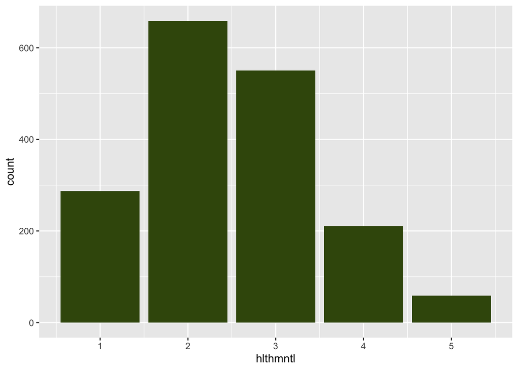

```r
#convert back to numeric
data_recode$hlthmntl <- as.numeric(data_recode$hlthmntl)

#mental health original
data_recode %>%  ggplot(aes(x= hlthmntl)) + geom_bar(fill = "#3D550C" )
```

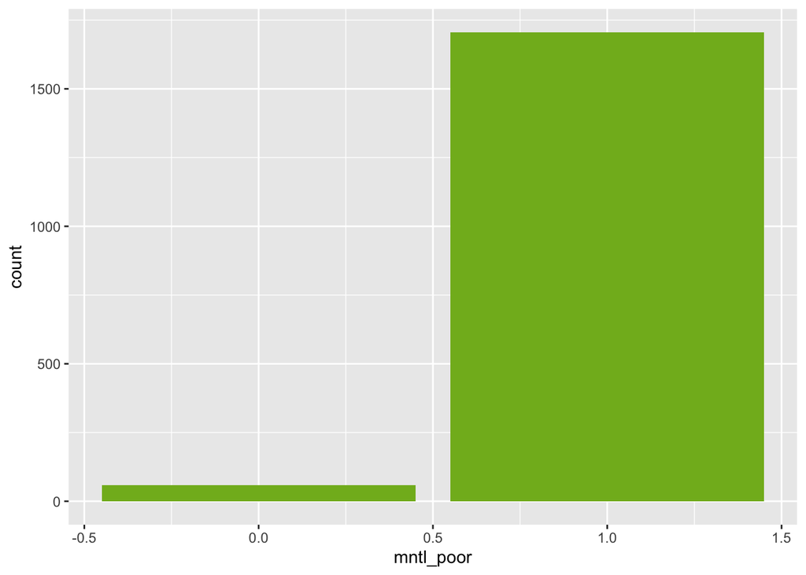

```r
#mental health binary split
data_poor %>%  ggplot(aes(x= mntl_poor)) + geom_bar(fill = "#81B622")
```

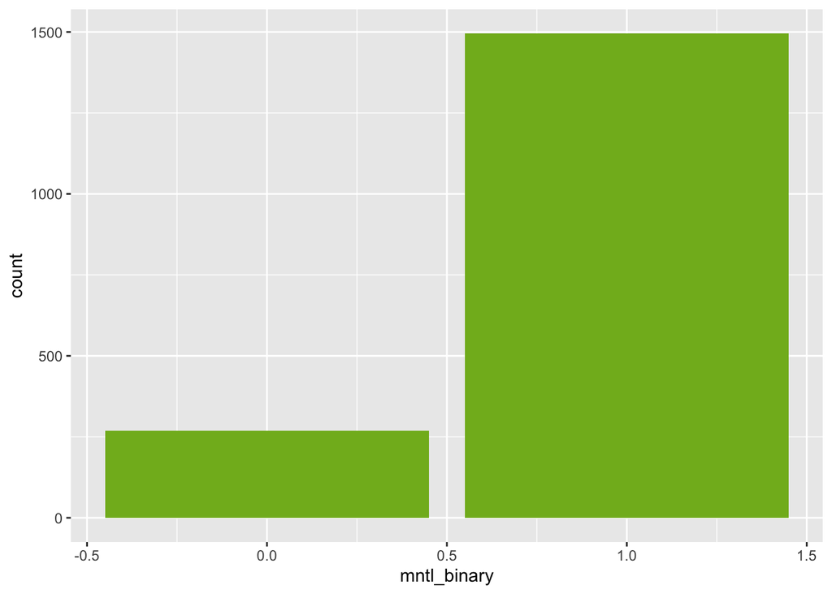

```r
#mental health split - poor only
data_recode %>%  ggplot(aes(x= mntl_binary)) + geom_bar(fill = "#81B622")
```

#### Bar Chart Visualization for activnat and mental_binary1

Examine the two variables as a proportional bar chart and bar chart.

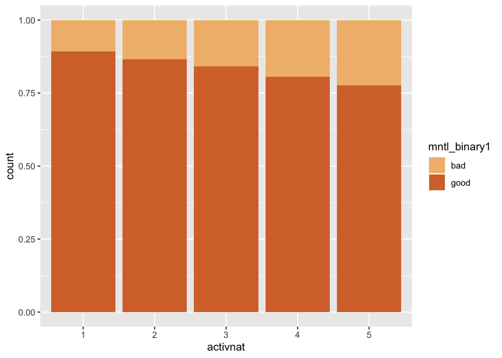

```r
#proportional bar chart
data_text %>%
  ggplot(aes(x = activnat, fill = mntl_binary1)) +
  geom_bar(position="fill") + scale_fill_manual(values = wes_palette(2, name = "GrandBudapest1", type = "continuous"))
```

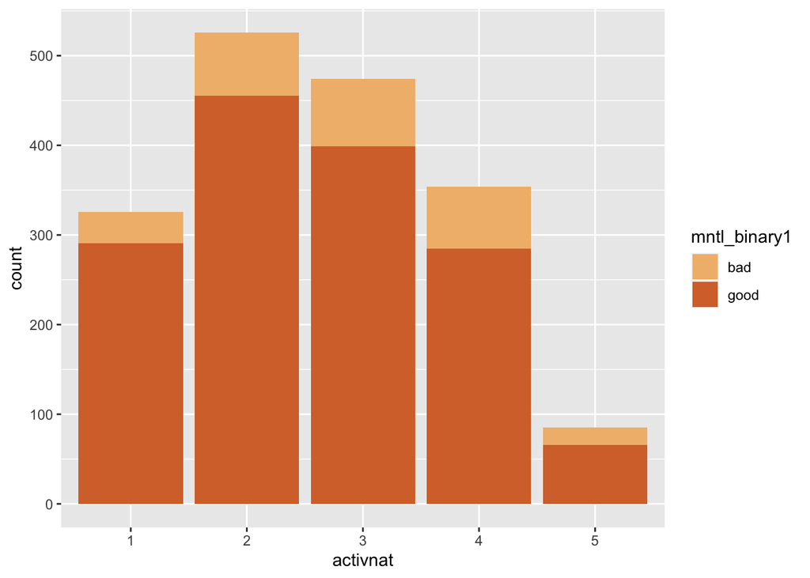

```r
#bar chart
data_text %>%
  ggplot(aes(x = activnat, fill = mntl_binary1)) +
  geom_bar(notch = TRUE) + scale_fill_manual(values = wes_palette(2, name = "GrandBudapest1", type = "continuous"))
```

## Logistic Regression #1

```r
summary(glm(mntl_binary~factor(activnat), family=binomial, data = data_recode)) #active in nature and mental health binary
```

```
##
## Call:
## glm(formula = mntl_binary ~ factor(activnat), family = binomial,
##     data = data_recode)
##
## Deviance Residuals:
##     Min       1Q   Median       3Q      Max
## -2.1126   0.4766   0.5385   0.5869   0.7113
##
## Coefficients:
##                   Estimate Std. Error z value Pr(>|z|)
## (Intercept)         2.1180     0.1789  11.839  < 2e-16 ***
## factor(activnat)2  -0.2604     0.2197  -1.185  0.23609
## factor(activnat)3  -0.4465     0.2187  -2.041  0.04122 *
## factor(activnat)4  -0.6996     0.2236  -3.128  0.00176 **
## factor(activnat)5  -0.8728     0.3159  -2.763  0.00573 **
## ---
## Signif. codes:  0 '***' 0.001 '**' 0.01 '*' 0.05 '.' 0.1 ' ' 1
##
## (Dispersion parameter for binomial family taken to be 1)
##
##     Null deviance: 1506.8  on 1764  degrees of freedom
## Residual deviance: 1492.2  on 1760  degrees of freedom
## AIC: 1502.2
##
## Number of Fisher Scoring iterations: 4
```

```r
#summary(glm(mntl_poor~factor(activnat), family=binomial, data = data_poor))#active in nature vs. poor health (NOT INCLUDED IN SLIDES)
```

#### Probabilities for Logistic Regression #1: Active in Nature and Mental Health Binary

```r
#daily (cat. 1)
exp(2.1180)/(exp(2.1180)+1)
```

```
## [1] 0.8926404
```

```r
#several times a week (cat. 2)
exp(2.1180 + -0.2604)/(exp(2.1180+ -0.2604)+1)
```

```
## [1] 0.865017
```

```r
#several times a month (cat. 3)
exp(2.1180 + -0.4465)/(exp(2.1180+ -0.4465)+1)
```

```
## [1] 0.8417757
```

```r
#several times a year (cat. 4)
exp(2.1180 + -0.6996)/(exp(2.1180+ -0.6996)+1)
```

```
## [1] 0.8050875
```

```r
#never (cat. 5)
exp(2.1180 + -0.8728)/(exp(2.1180+ -0.8728)+1)
```

```
## [1] 0.7764679
```

```r
0.8926404/0.7764679-1 #cat. 1 is bigger than cat.5 by this much
```

```
## [1] 0.1496166
```

## Logistic Regression #2: Making Independent Variables for Activity in Nature Continuous

1. DAILY 1 -> 365 days

2. SEVERAL TIMES A WEEK 2 -> 4*4*12 = 192 days

3. SEVERAL TIMES A MONTH 3 -> 4*12 = 48 days

4. SEVERAL TIMES A YEAR 4 -> 4*1 = 4 days

5. NEVER 5 -> 0 days

```r
#convert to continuous
data_nature <- data_recode %>%
  mutate(nature_cont = case_when(
  activnat == 1 ~ 365,
  activnat == 2 ~ 192,
  activnat == 3 ~ 48,
  activnat == 4 ~ 4,
  activnat == 5 ~ 0,
))
data_nature
```

| id | hlthmntl | incom16 | activnat | hlthphys | income16 | mntl_binary | nature_cont |
| --- | --- | --- | --- | --- | --- | --- | --- |
| 6 | 2 | 3 | 4 | 1 | NA(d) | 1 | 4 |
| 7 | 3 | 3 | 4 | 3 | NA(d) | 1 | 4 |
| 8 | 4 | 3 | 3 | 3 | 22 | 0 | 48 |
| 9 | 2 | 3 | 2 | 2 | 22 | 1 | 192 |
| 13 | 4 | 2 | 3 | 4 | 21 | 0 | 48 |
| 16 | 4 | 4 | 3 | 4 | NA(d) | 0 | 48 |
| 17 | 1 | 3 | 3 | 3 | 26 | 1 | 48 |
| 23 | 3 | 2 | 4 | 3 | 21 | 1 | 4 |
| 25 | 4 | 3 | 4 | 4 | 25 | 0 | 4 |
| 28 | 2 | 2 | 4 | 2 | 25 | 1 | 4 |

[output cut: 1755 more lines]

```r
#test out logistic regressions
summary(glm(mntl_binary~factor(activnat), family=binomial, data = data_recode)) #active in nature and mental health binary
```

```
##
## Call:
## glm(formula = mntl_binary ~ factor(activnat), family = binomial,
##     data = data_recode)
##
## Deviance Residuals:
##     Min       1Q   Median       3Q      Max
## -2.1126   0.4766   0.5385   0.5869   0.7113
##
## Coefficients:
##                   Estimate Std. Error z value Pr(>|z|)
## (Intercept)         2.1180     0.1789  11.839  < 2e-16 ***
## factor(activnat)2  -0.2604     0.2197  -1.185  0.23609
## factor(activnat)3  -0.4465     0.2187  -2.041  0.04122 *
## factor(activnat)4  -0.6996     0.2236  -3.128  0.00176 **
## factor(activnat)5  -0.8728     0.3159  -2.763  0.00573 **
## ---
## Signif. codes:  0 '***' 0.001 '**' 0.01 '*' 0.05 '.' 0.1 ' ' 1
##
## (Dispersion parameter for binomial family taken to be 1)
##
##     Null deviance: 1506.8  on 1764  degrees of freedom
## Residual deviance: 1492.2  on 1760  degrees of freedom
## AIC: 1502.2
##
## Number of Fisher Scoring iterations: 4
```

```r
summary(glm(mntl_binary~nature_cont, family=binomial, data = data_nature)) #active in nature and mental health binary
```

```
##
## Call:
## glm(formula = mntl_binary ~ nature_cont, family = binomial, data = data_nature)
##
## Deviance Residuals:
##     Min       1Q   Median       3Q      Max
## -2.1332   0.4657   0.5433   0.6161   0.6421
##
## Coefficients:
##              Estimate Std. Error z value Pr(>|z|)
## (Intercept) 1.4743232  0.0918602  16.050  < 2e-16 ***
## nature_cont 0.0018971  0.0005439   3.488 0.000487 ***
## ---
## Signif. codes:  0 '***' 0.001 '**' 0.01 '*' 0.05 '.' 0.1 ' ' 1
##
## (Dispersion parameter for binomial family taken to be 1)
##
##     Null deviance: 1506.8  on 1764  degrees of freedom
## Residual deviance: 1494.0  on 1763  degrees of freedom
## AIC: 1498
##
## Number of Fisher Scoring iterations: 4
```

#### Further Testing Data and Probabilities

```r
#y= beta zero + beta one (days in nature)
-1.4743232 + -0.0018971*48
```

```
## [1] -1.565384
```

```r
-1.4743232 + -0.0018971*192
```

```
## [1] -1.838566
```

```r
0.2289336/(0.2289336+1) #intercept
```

```
## [1] 0.1862864
```

```r
0.2284997/(0.2284997+1)
```

```
## [1] 0.185999
```

```r
0.03641082/( 0.03641082+1)
```

```
## [1] 0.03513165
```

```r
exp(-1.4743232)
```

```
## [1] 0.2289336
```

```r
exp(-0.0018971)*exp(-1.4743232)
```

```
## [1] 0.2284997
```

```r
exp(-1.838566)*exp(-1.4743232)
```

```
## [1] 0.03641082
```

```r
data_recode %>% count(mntl_binary)
```

| mntl_binary | n |
| --- | --- |
| 0 | 269 |
| 1 | 1496 |

```r
table(data_recode$mntl_binary, data_recode$activnat) #create table
```

```
##
##       1   2   3   4   5
##   0  35  71  75  69  19
##   1 291 455 399 285  66
```

#### Calculating Probability for Days in Nature

```r
#48 days
0.0918602+(0.0018971*48)
```

```
## [1] 0.182921
```

```r
exp(0.182921)/(exp(0.182921)+1) #probability
```

```
## [1] 0.5456032
```

```r
#192 days
0.0918602+(0.0018971*192)
```

```
## [1] 0.4561034
```

```r
exp(0.4561034)/(exp(0.4561034)+1) #probability
```

```
## [1] 0.6120894
```

```r
#365 days
0.0918602+(0.0018971*365)
```

```
## [1] 0.7843017
```

```r
exp(0.7843017)/(exp(0.7843017)+1) #probability
```

```
## [1] 0.6866065
```

#### Making Confounding Variable (Income16) Continuous

```r
#convert to numeric
data_nature$income16 <- as.numeric(data_nature$income16)

data_coded <- data_nature %>% drop_na(income16) %>%
  mutate(income = case_when(income16 == "1" ~ 500,
                            income16 == "2" ~ 1999.5,
                            income16 == "3" ~ 3499.5,
                            income16 == "4" ~ 4499.5,
                            income16 == "5" ~ 5499.5,
                            income16 == "6" ~ 6499.5,
                            income16 == "7" ~ 7499.5,
                            income16 == "8" ~ 8999.5,
                            income16 == "9" ~ 11249.5,
                            income16 == "10" ~ 13749.5,
                            income16 == "11" ~ 16249.5,
                            income16 == "12" ~ 18749.5,
                            income16 == "13" ~ 21249.5,
                            income16 == "14" ~ 23749.5,
                            income16 == "15" ~ 27499.5,
                            income16 == "16" ~ 32499.5,
                            income16 == "17" ~ 37499.5,
                            income16 == "18" ~ 44999.5,
                            income16 == "19" ~ 54999.5,
                            income16 == "20" ~ 67499.5,
                            income16 == "21" ~ 82499.5,
                            income16 == "22" ~ 99999.5,
                            income16 == "23" ~ 119999.5,
                            income16 == "24" ~ 139999.5,
                            income16 == "25" ~ 159999.5,
                            income16 == "26" ~ 200000)) #assumed for highest amount since it's $170,000 OR OVER
data_coded
```

| id | hlthmntl | incom16 | activnat | hlthphys | income16 | mntl_binary | nature_cont | income |
| --- | --- | --- | --- | --- | --- | --- | --- | --- |
| 8 | 4 | 3 | 3 | 3 | 22 | 0 | 48 | 99999.5 |
| 9 | 2 | 3 | 2 | 2 | 22 | 1 | 192 | 99999.5 |
| 13 | 4 | 2 | 3 | 4 | 21 | 0 | 48 | 82499.5 |
| 17 | 1 | 3 | 3 | 3 | 26 | 1 | 48 | 200000.0 |
| 23 | 3 | 2 | 4 | 3 | 21 | 1 | 4 | 82499.5 |
| 25 | 4 | 3 | 4 | 4 | 25 | 0 | 4 | 159999.5 |
| 28 | 2 | 2 | 4 | 2 | 25 | 1 | 4 | 159999.5 |
| 31 | 1 | 4 | 4 | 1 | 26 | 1 | 4 | 200000.0 |
| 36 | 4 | 2 | 4 | 4 | 20 | 0 | 4 | 67499.5 |
| 37 | 3 | 3 | 2 | 1 | 26 | 1 | 192 | 200000.0 |

[output cut: 1590 more lines]

#### Making Confounding Variable (Physical Health) Binary

```r
#recoding the poor and fair grouped vs. all other
data_confounder <- data_coded %>%
  mutate(phys_binary = case_when(
  hlthphys == 1 ~ 1,
  hlthphys == 2 ~ 1,
  hlthphys == 3 ~ 1,
  hlthphys == 4 ~ 0,
  hlthphys == 5 ~ 0
))
data_confounder
```

| id | hlthmntl | incom16 | activnat | hlthphys | income16 | mntl_binary | nature_cont | income | phys_binary |
| --- | --- | --- | --- | --- | --- | --- | --- | --- | --- |
| 8 | 4 | 3 | 3 | 3 | 22 | 0 | 48 | 99999.5 | 1 |
| 9 | 2 | 3 | 2 | 2 | 22 | 1 | 192 | 99999.5 | 1 |
| 13 | 4 | 2 | 3 | 4 | 21 | 0 | 48 | 82499.5 | 0 |
| 17 | 1 | 3 | 3 | 3 | 26 | 1 | 48 | 200000.0 | 1 |
| 23 | 3 | 2 | 4 | 3 | 21 | 1 | 4 | 82499.5 | 1 |
| 25 | 4 | 3 | 4 | 4 | 25 | 0 | 4 | 159999.5 | 0 |
| 28 | 2 | 2 | 4 | 2 | 25 | 1 | 4 | 159999.5 | 1 |
| 31 | 1 | 4 | 4 | 1 | 26 | 1 | 4 | 200000.0 | 1 |
| 36 | 4 | 2 | 4 | 4 | 20 | 0 | 4 | 67499.5 | 0 |
| 37 | 3 | 3 | 2 | 1 | 26 | 1 | 192 | 200000.0 | 1 |

[output cut: 1590 more lines]

## Logistic Regression #3: Adding Confounding Variables

```r
#factor categorical version of activnat
summary(glm(mntl_binary~factor(activnat) + factor(phys_binary) + income, family=binomial,data = data_confounder))
```

```
##
## Call:
## glm(formula = mntl_binary ~ factor(activnat) + factor(phys_binary) +
##     income, family = binomial, data = data_confounder)
##
## Deviance Residuals:
##     Min       1Q   Median       3Q      Max
## -2.7379   0.2612   0.3938   0.4839   1.3248
##
## Coefficients:
##                        Estimate Std. Error z value Pr(>|z|)
## (Intercept)           4.276e-02  2.396e-01   0.178    0.858
## factor(activnat)2    -2.003e-01  2.540e-01  -0.789    0.430
## factor(activnat)3    -3.629e-01  2.536e-01  -1.431    0.153
## factor(activnat)4    -4.201e-01  2.601e-01  -1.615    0.106
## factor(activnat)5    -2.478e-01  3.900e-01  -0.635    0.525
## factor(phys_binary)1  2.018e+00  1.596e-01  12.645  < 2e-16 ***
## income                8.319e-06  1.673e-06   4.974 6.56e-07 ***
## ---
## Signif. codes:  0 '***' 0.001 '**' 0.01 '*' 0.05 '.' 0.1 ' ' 1
##
## (Dispersion parameter for binomial family taken to be 1)
##
##     Null deviance: 1358.7  on 1586  degrees of freedom
## Residual deviance: 1107.6  on 1580  degrees of freedom
##   (13 observations deleted due to missingness)
## AIC: 1121.6
##
## Number of Fisher Scoring iterations: 5
```

```r
#continuous version of activnat
summary(glm(mntl_binary ~ nature_cont + factor(phys_binary) + income, family=binomial,data = data_confounder))  #NOT IN FINAL SLIDES
```

```
##
## Call:
## glm(formula = mntl_binary ~ nature_cont + factor(phys_binary) +
##     income, family = binomial, data = data_confounder)
##
## Deviance Residuals:
##     Min       1Q   Median       3Q      Max
## -2.7321   0.2606   0.3955   0.4842   1.3139
##
## Coefficients:
##                        Estimate Std. Error z value Pr(>|z|)
## (Intercept)          -3.567e-01  1.576e-01  -2.264   0.0236 *
## nature_cont           1.079e-03  6.240e-04   1.730   0.0837 .
## factor(phys_binary)1  2.017e+00  1.593e-01  12.665  < 2e-16 ***
## income                8.267e-06  1.665e-06   4.965 6.87e-07 ***
## ---
## Signif. codes:  0 '***' 0.001 '**' 0.01 '*' 0.05 '.' 0.1 ' ' 1
##
## (Dispersion parameter for binomial family taken to be 1)
##
##     Null deviance: 1358.7  on 1586  degrees of freedom
## Residual deviance: 1107.9  on 1583  degrees of freedom
##   (13 observations deleted due to missingness)
## AIC: 1115.9
##
## Number of Fisher Scoring iterations: 5
```

#### Logistic Regression #3 Probabilities

```r
exp(0.042762183+(0.000008319*4499.5))/(exp( 0.042762183+(0.000008319*4499.5))+1) #mean value of originally category 4
```

```
## [1] 0.5200376
```

```r
exp(0.042762183+(0.000008319*139999.5))/(exp( 0.042762183+(0.000008319*139999.5))+1) #mean value of originally category 24
```

```
## [1] 0.7698418
```

```r
exp(0.042762183+(0.000008319*40000))/(exp( 0.042762183+(0.000008319*40000))+1) #$40K income
```

```
## [1] 0.5927927
```

```r
exp(0.042762183+(0.000008319*50000))/(exp( 0.042762183+(0.000008319*50000))+1) #$50K income
```

```
## [1] 0.6127086
```

```r
exp(0.042762183+(0.000008319*60000))/(exp( 0.042762183+(0.000008319*60000))+1) #$60k income
```

```
## [1] 0.6322548
```

```r
exp(0.042762183+(0.000008319*70000))/(exp( 0.042762183+(0.000008319*70000))+1) #$70k income
```

```
## [1] 0.6513758
```

```r
exp(0.042762183+(0.000008319*80000))/(exp( 0.042762183+(0.000008319*80000))+1) #$80k income
```

```
## [1] 0.6700215
```

```r
exp(0.042762183+(0.000008319*100000))/(exp( 0.042762183+(0.000008319*100000))+1) #$100k income
```

```
## [1] 0.7057149
```

#### Logistic Regression: Confounding Variables with Interaction Coefficients

```r
#factor categorical version of activnat
summary(glm(mntl_binary~factor(activnat) * factor(phys_binary) + factor(activnat) * income, family=binomial,data = data_confounder)) #NOT IN FINAL SLIDES
```

```
##
## Call:
## glm(formula = mntl_binary ~ factor(activnat) * factor(phys_binary) +
##     factor(activnat) * income, family = binomial, data = data_confounder)
##
## Deviance Residuals:
##     Min       1Q   Median       3Q      Max
## -2.7402   0.2728   0.4049   0.4693   1.3524
##
## Coefficients:
##                                          Estimate Std. Error z value Pr(>|z|)
## (Intercept)                             3.095e-01  3.712e-01   0.834   0.4044
## factor(activnat)2                      -6.592e-01  4.604e-01  -1.432   0.1522
## factor(activnat)3                      -7.007e-01  4.659e-01  -1.504   0.1326
## factor(activnat)4                      -4.902e-01  4.624e-01  -1.060   0.2891
## factor(activnat)5                      -9.199e-01  7.161e-01  -1.285   0.1989
## factor(phys_binary)1                    1.842e+00  4.411e-01   4.176 2.96e-05
## income                                  5.604e-06  3.888e-06   1.441   0.1495
## factor(activnat)2:factor(phys_binary)1 -7.933e-02  5.376e-01  -0.148   0.8827
## factor(activnat)3:factor(phys_binary)1  3.449e-01  5.353e-01   0.644   0.5194
## factor(activnat)4:factor(phys_binary)1  3.468e-01  5.451e-01   0.636   0.5245
## factor(activnat)5:factor(phys_binary)1  1.646e-01  8.099e-01   0.203   0.8390
## factor(activnat)2:income                8.881e-06  5.378e-06   1.651   0.0987
## factor(activnat)3:income                2.274e-06  4.943e-06   0.460   0.6456
## factor(activnat)4:income               -2.099e-06  5.077e-06  -0.414   0.6792
## factor(activnat)5:income                1.289e-05  1.067e-05   1.208   0.2272
##
## (Intercept)
## factor(activnat)2
## factor(activnat)3
## factor(activnat)4
## factor(activnat)5
## factor(phys_binary)1                   ***
## income
## factor(activnat)2:factor(phys_binary)1
## factor(activnat)3:factor(phys_binary)1
## factor(activnat)4:factor(phys_binary)1
## factor(activnat)5:factor(phys_binary)1
## factor(activnat)2:income               .
## factor(activnat)3:income
## factor(activnat)4:income
## factor(activnat)5:income
## ---
## Signif. codes:  0 '***' 0.001 '**' 0.01 '*' 0.05 '.' 0.1 ' ' 1
##
## (Dispersion parameter for binomial family taken to be 1)
##
##     Null deviance: 1358.7  on 1586  degrees of freedom
## Residual deviance: 1099.9  on 1572  degrees of freedom
##   (13 observations deleted due to missingness)
## AIC: 1129.9
##
## Number of Fisher Scoring iterations: 6
```

```r
#continuous version of activnat
summary(glm(mntl_binary ~ nature_cont * factor(phys_binary) + nature_cont * income, family=binomial,data = data_confounder))
```

```
##
## Call:
## glm(formula = mntl_binary ~ nature_cont * factor(phys_binary) +
##     nature_cont * income, family = binomial, data = data_confounder)
##
## Deviance Residuals:
##     Min       1Q   Median       3Q      Max
## -2.7644   0.2620   0.3947   0.4823   1.3319
##
## Coefficients:
##                                    Estimate Std. Error z value Pr(>|z|)
## (Intercept)                      -3.966e-01  1.966e-01  -2.017  0.04369 *
## nature_cont                       1.466e-03  1.129e-03   1.298  0.19440
## factor(phys_binary)1              2.151e+00  2.187e-01   9.835  < 2e-16 ***
## income                            7.664e-06  2.333e-06   3.285  0.00102 **
## nature_cont:factor(phys_binary)1 -1.182e-03  1.291e-03  -0.915  0.35993
## nature_cont:income                5.587e-09  1.328e-08   0.421  0.67394
## ---
## Signif. codes:  0 '***' 0.001 '**' 0.01 '*' 0.05 '.' 0.1 ' ' 1
##
## (Dispersion parameter for binomial family taken to be 1)
##
##     Null deviance: 1358.7  on 1586  degrees of freedom
## Residual deviance: 1107.0  on 1581  degrees of freedom
##   (13 observations deleted due to missingness)
## AIC: 1119
##
## Number of Fisher Scoring iterations: 5
```

```r
#testing Pseudo R-Squared
r.glm  <- glm(mntl_binary~factor(activnat),family=binomial, data = data_recode)
PseudoR2(r.glm, which = "McFadden")
```

```
##    McFadden
## 0.009701578
```

```r
r.glm  <- glm(mntl_binary~factor(activnat)*factor(phys_binary) + activnat*income,family=binomial, data = data_confounder)
PseudoR2(r.glm, which = "McFadden")
```

```
## McFadden
##  0.19053
```

## Likelihood Ratio Test: Logistic Regression #1 vs. #3

```r
options(scipen = 900) #get rid of scientific notation

#drop any additional NAs
data_model <- data_confounder %>% drop_na(activnat,phys_binary,mntl_binary, income, incom16)

#fit full model
model_full <- glm(mntl_binary ~ factor(activnat) + phys_binary + income, data = data_model)

#fit reduced model
model_reduced <- glm(mntl_binary ~ factor(activnat), data = data_model)

#perform likelihood ratio test for differences in models
lrtest(model_full, model_reduced)
```

|  | #Df | LogLik | Df | Chisq | Pr(>Chisq) |
| --- | --- | --- | --- | --- | --- |
| 1 | 8 | -468.8214 | NA | NA | NA |
| 2 | 6 | -622.9764 | -2 | 308.3098 | 0.0000000000000000000000000000000000000000000000000000000000000000001125583 |